# Fluxos, Fragmentação, Resiliência e Vulnerabilidade

Análise da Paisagem · Aula 4.1

Prof. Dr. Luiz Diego Vidal Santos

## Visão Geral da Aula

### Tópicos

- 1 Fluxos na paisagem: matéria, energia e organismos
- 2 Permeabilidade da matriz e movimento
- 3 Bordas: efeitos e consequências
- 4 Fragmentação como processo multiescalar
- 5 Resiliência e vulnerabilidade socioambiental
- 6 Limiares em paisagens sob pressão

**Objetivo da Aula**

Compreender os **fluxos** que atravessam a paisagem, os efeitos da **fragmentação** e dos **bordas** sobre esses fluxos, e os conceitos de **resiliência** e **vulnerabilidade** aplicados ao diagnóstico territorial.

# FLUXOS NA PAISAGEM

## A paisagem como sistema de fluxos

### Fluxos de matéria

| Fluxo | Origem → Destino | Condicionante |
| --- | --- | --- |
| **Água** | Precipitação → escoamento → drenagem | Permeabilidade do solo, cobertura vegetal |
| **Sedimentos** | Erosão → transporte → deposição | Declividade, proteção do solo |
| **Nutrientes** | Rocha → solo → planta → serrapilheira | Ciclagem biogeoquímica |
| **Poluentes** | Fonte → dispersão → acumulação | Vento, água, relevo |

### Fluxos de energia

- Radiação solar → fotossíntese → biomassa
- Energia cinética da chuva → impacto → erosividade
- Energia gravitacional → movimentos de massa
- Calor → balanço de energia → evapotranspiração

**Fluxos de organismos**

Os organismos se movimentam pela paisagem em função de:

- **Dispersão** - juvenis procurando novos territórios
- **Migração** - movimentos sazonais
- **Forrageamento** - busca diária por alimento
- **Polinização** - insetos entre plants

### O que controla os fluxos?

1. **Estrutura da paisagem** - arranjo de manchas, corredores e matriz
2. **Conectividade** - existência de vias de conexão
3. **Barreiras** - elementos que impedem ou filtram
4. **Permeabilidade** - grau em que a matriz permite passagem

> *“Modificar a estrutura da paisagem é modificar seus fluxos - e vice-versa.”*

## Fluxos e arranjo espacial

### O arranjo muda o fluxo

Considere duas paisagens com a **mesma proporção** de floresta (30%) e pastagem (70%):

**Paisagem A:** floresta concentrada em um grande bloco

- Fluxo de organismos: alto **dentro**, baixo **entre** (não há manchas separadas)
- Proteção do solo: concentrada
- Serviços ecossistêmicos: localizados

**Paisagem B:** floresta distribuída em muitos fragmentos pequenos

- Fluxo de organismos: depende da conectividade
- Proteção do solo: dispersa, mas cada mancha protege pouco
- Serviços ecossistêmicos: difusos, mas possivelmente insuficientes

**Configuração importa**

A **composição** (quanto de cada cobertura) não é suficiente - a **configuração** (como estão arranjadas) é igualmente importante.

| Aspecto | Composição | Configuração |
| --- | --- | --- |
| **O que mede** | Proporção de cada classe | Arranjo espacial das classes |
| **Exemplo** | 30% floresta, 70% pastagem | 1 fragmento grande vs. 100 pequenos |
| **Métrica** | % de cobertura | Fragmentação, isolamento, forma |

> A ecologia da paisagem mostrou que **configuração** pode ser tão determinante quanto composição para os processos ecológicos.

# PERMEABILIDADE DA MATRIZ

## Conceito de permeabilidade

### Definição

A **permeabilidade** é o grau em que a matriz permite o movimento de organismos entre manchas de habitat.

### Fatores que determinam a permeabilidade

1. **Tipo de cobertura** da matriz
   - Vegetação secundária → alta permeabilidade
   - Pastagem com árvores → média
   - Monocultura mecanizada → baixa
   - Área urbana densa → muito baixa
2. **Estrutura vertical** - presença de estratos (herbáceo, arbustivo, arbóreo)
3. **Presença de obstáculos** - cercas, estradas, cursos d’água sem mata ciliar
4. **Espécie focal** - cada espécie tem diferente sensibilidade à matriz

**Classificação da matriz**

| Tipo de matriz | Permeabilidade | Custo de deslocamento |
| --- | --- | --- |
| Floresta secundária | Alta | Baixo (1-5) |
| Silvicultura (eucalipto) | Média-alta | Baixo-médio (5-15) |
| Pastagem com árvores | Média | Médio (20-40) |
| Pastagem limpa | Baixa | Alto (40-80) |
| Monocultura (soja, cana) | Muito baixa | Muito alto (60-100) |
| Área urbana | Variável (pode ser barreira) | Muito alto (100-500) |
| Rodovia pavimentada | Barreira | Máximo (1000) |

> Melhorar a **qualidade da matriz** (agrofloresta, cercas vivas, silvipastoril) é uma estratégia de conservação **tão importante** quanto criar novas áreas protegidas.

# BORDAS: EFEITOS E CONSEQUÊNCIAS

## Efeito de borda em detalhe

### Gradiente de borda

A borda não é uma **linha** - é uma **zona de transição** com gradiente:

| Variável | Interior | Borda | Matriz |
| --- | --- | --- | --- |
| Temperatura | Baixa, estável | Intermediária | Alta, variável |
| Umidade | Alta | Intermediária | Baixa |
| Luminosidade | Baixa | Alta | Muito alta |
| Vento | Fraco | Forte | Forte |
| Espécies de interior | Muitas | Poucas | Ausentes |
| Espécies generalistas | Poucas | Muitas | Muitas |
| Invasoras | Raras | Frequentes | Comuns |

**Profundidade do efeito de borda**

A penetração do efeito depende do **tipo de efeito** e do **ecossistema**:

| Efeito | Penetração típica |
| --- | --- |
| Microclima (T, umidade) | 50-100 m |
| Invasão de espécies | 100-200 m |
| Mortalidade de árvores | 100-300 m |
| Mudança na composição de aves | 200-500 m |
| Alteração na ciclagem de nutrientes | 50-150 m |

### Consequência

Em fragmento florestal de **10 ha** (circular, raio ~178 m):

- Se o efeito de borda penetra **100 m**, a **área-núcleo** é apenas **~1,9 ha** (19%)!
- Fragmentos < 25 ha em Mata Atlântica podem ser **100% borda**

> Fragmentos pequenos podem ser **inteiramente dominados** pelo efeito de borda.

# FRAGMENTAÇÃO COMO PROCESSO

## Estágios da fragmentação

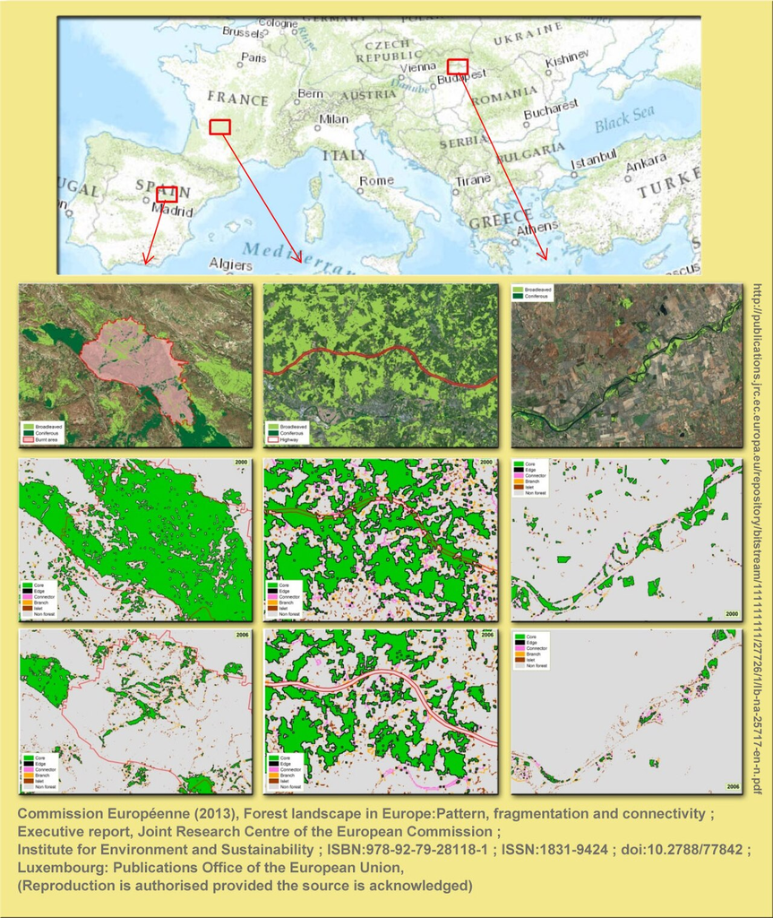

Estágios da fragmentação florestal na Europa

### Modelo de Forman (1995)

A fragmentação típica segue estágios:

1. **Perfuração** (*perforation*) - surgem “buracos” na cobertura original
2. **Dissecção** (*dissection*) - vias lineares cortam a cobertura (estradas, canais)
3. **Fragmentação** (*fragmentation*) - a cobertura se divide em manchas menores
4. **Encolhimento** (*shrinkage*) - manchas remanescentes diminuem
5. **Atricção/eliminação** (*attrition*) - manchas menores desaparecem

### Obs.: nem toda paisagem segue essa sequência

Processos podem ocorrer **simultaneamente** ou em ordem diferente - o modelo é uma **referência**, não uma lei.

**Limiares de fragmentação**

A teoria das **percolações** sugere que:

- Quando a paisagem tem **≥ 60% de habitat**, a cobertura tende a ser **conectada** (contínua)
- Abaixo de **~30%**, os fragmentos ficam **isolados** e a conectividade colapsa
- Entre **30-60%**, a paisagem está numa zona crítica - pequenas mudanças provocam grandes efeitos

### Limiar de extinção

- Para muitas espécies, existir **20-30% de habitat** na paisagem é o **mínimo** para manter populações viáveis
- Abaixo disso, a extinção local se torna provável (“dívida de extinção”)

> *“A fragmentação não é um problema linear - é um problema de limiares. Cruzar o limiar pode ser irreversível.”*

## Débito de extinção: a conta atrasada

### O conceito

A resposta das espécies à perda de hábitat **não é imediata** - existe um *time lag* (atraso) entre a perturbação e a extinção local efetiva.

> Analogia: é como o **cartão de crédito** - você gastou agora, mas a fatura chega depois. A natureza foi impactada hoje; as extinções só serão observadas anos ou décadas à frente.

### Magnitude do *time lag* (revisão de 83 estudos)

- Variação: **5 a 570 anos**
- Mediana em torno de **≈ 100 anos** para a maioria dos grupos
- Atinge entre **9 % e 90 %** das espécies atuais, dependendo do grupo
- **Maior** em organismos longevos (onças, árvores) e fragmentos pequenos
- **Menor** em organismos de ciclo curto (insetos, anuárias)

**Hipótese da quantidade de hábitat (Fahrig, 2003 ss.)**

A quantidade total de hábitat no entorno explica mais a riqueza de espécies do que a configuração (número/forma dos fragmentos).

→ Implicação: **proteger área é prioridade**, ainda que a configuração também importe.

**Caso brasileiro: Pontal do Paranapanema (SP)**

A composição atual da comunidade de **aves** respondeu mais à estrutura da paisagem de **1978** do que à estrutura atual:

- *time lag* observado: **≈ 25 anos**
- Pequenos fragmentos: extinções locais futuras já “contratadas”
- Persistência tende a se concentrar nos **grandes fragmentos** (ex.: Morro do Diabo)

**Implicação para a gestão:** estamos manejando hoje paisagens cuja resposta biológica plena só será visível décadas à frente.

## Métricas de fragmentação (introdução)

### Métricas-chave (serão aprofundadas nas Aulas 17-18)

| Métrica | O que mede | Interpretação |
| --- | --- | --- |
| **Número de manchas** (NP) | Quantidade de fragmentos | Mais manchas = mais fragmentado |
| **Área média** (AREA_MN) | Tamanho médio dos fragmentos | Menor = mais fragmentado |
| **Distância ao vizinho** (ENN_MN) | Isolamento entre manchas | Maior = mais isolado |
| **Índice de forma** (SHAPE) | Complexidade do formato | Mais irregular = mais borda |
| **Área-núcleo** (CORE) | Área livre de efeito de borda | Menor = mais degradado |

**Onde calcular?**

- **FRAGSTATS** - software clássico (McGarigal et al., 2012)
- **landscapemetrics** - pacote em R
- **LecoS** - plugin para QGIS
- **Graphab** - conectividade funcional

### Dados necessários

1. Mapa de **uso e cobertura** da terra (raster classificado)
2. Definição da **classe de interesse** (habitat)
3. Resolução adequada (pixel 10-30 m para escala de paisagem)

> Na **Aula 19** trabalharemos com essas métricas em exercício prático.

## Modelos neutros e validação de padrões

### O problema

Quando calculamos métricas de fragmentação, como saber se o padrão observado é resultado de um **processo ecológico real** ou apenas de uma **distribuição aleatória** de cobertura?

### Modelos neutros da paisagem

Gardner et al. (1987) propuseram gerar **paisagens sintéticas aleatórias** com a mesma proporção de habitat (PLAND) e extensão da paisagem real.

**Procedimento:**

1. Gerar 100-1000 paisagens aleatórias com mesmo PLAND
2. Calcular métricas para cada paisagem simulada
3. Construir distribuição nula
4. Comparar valores observados com a distribuição nula

> Se NP_real >> NP_neutro → processo de fragmentação ativo  
> Se AI_real >> AI_neutro → autocorrelação espacial (sucessão, legislação)

**Limiar de percolação teórico**

Em paisagens binárias aleatórias (With & King, 1997), o **limiar de percolação** ocorre em PLAND ≈ 59,28%.

Abaixo desse valor, a conectividade colapsa em paisagens aleatórias. Se a paisagem real mantém conectividade com PLAND < 59%, isso indica que a **configuração espacial** (não apenas a quantidade) está preservando a conectividade.

### Aplicação prática

Em paisagens de Mata Atlântica com PLAND entre 5-25%, a agregação de floresta em topos de morro e ao longo de cursos d’água é **significativamente superior** à esperada por distribuição aleatória → evidência do efeito combinado de:

- Topografia
- Legislação de APPs
- Histórico de uso (preservação de áreas íngremes)

**Referências:**  
Gardner et al. (1987) *Landscape Ecology*  
With & King (1997) *Oikos*

# RESILIÊNCIA E VULNERABILIDADE

## Resiliência da paisagem

[figure not shown]

### Definição

> **Resiliência** é a capacidade de um sistema (paisagem) de absorver perturbação e manter suas funções essenciais, ou de retornar a um estado funcional após o distúrbio.

### Dois tipos de resiliência

| Tipo | Significado |
| --- | --- |
| **Engenharia** | Velocidade de retorno ao estado original após perturbação |
| **Ecológica** | Magnitude da perturbação que o sistema suporta antes de mudar de estado |

### O que aumenta a resiliência?

- **Heterogeneidade** - paisagens diversas têm mais opções de resposta
- **Conectividade** - permite recolonização após distúrbio
- **Redundância funcional** - várias espécies desempenham funções similares
- **Área protegida** - refúgio para espécies e processos

**O que reduz a resiliência?**

- **Fragmentação intensa** - isolamento, perda de espécies
- **Simplificação** - monocultura, homogeneização
- **Degradação acumulada** - erosão, perda de solo, desertificação
- **Pressão contínua** - sem tempo de recuperação
- **Mudanças climáticas** - stress adicional ao sistema

### Exemplo: resiliência da caatinga

A caatinga possui alta resiliência **natural** (plantas deciduais, banco de sementes, rebrota). Porém:

- Sobrepastejo + corte raso + queimadas → esgotam a capacidade de rebrota
- Solo exposto → erosão → perda irreversível
- Desertificação como **mudança de estado** - nova paisagem, não mais reversível

> *“A resiliência não é infinita. Toda paisagem tem um limiar.”*

## Vulnerabilidade socioambiental

### Definição (IPCC, adaptada)

> **Vulnerabilidade** = f(Exposição, Sensibilidade, Capacidade adaptativa)

| Componente | Significado | Exemplo na paisagem |
| --- | --- | --- |
| **Exposição** | Grau em que o sistema está sujeito a pressões | Área em zona de risco climático, leito de inundação |
| **Sensibilidade** | Grau em que o sistema é afetado pela pressão | Solo frágil, vegetação degradada, encosta íngreme |
| **Capacidade adaptativa** | Capacidade de ajuste ou resposta | Vegetação resiliente, gestão eficiente, recursos financeiros |

**Avaliação da vulnerabilidade da paisagem**

Para diagnosticar vulnerabilidade:

1. **Mapear exposição** - quais áreas estão sob pressão? (seca, inundação, expansão urbana)
2. **Avaliar sensibilidade** - características que amplificam o impacto (declividade, tipo de solo, cobertura)
3. **Estimar capacidade adaptativa** - fatores que mitigam (vegetação conservada, gestão, infraestrutura)

### Resultado

**Vulnerabilidade alta** = exposição alta + sensibilidade alta + capacidade adaptativa baixa

> Paisagens do semiárido baiano com solo raso, vegetação degradada e sem gestão ambiental = **alta vulnerabilidade** à desertificação.

# LIMIARES EM PAISAGENS SOB PRESSÃO

## Mudanças de estado e irreversibilidade

### Conceito de limiar (*threshold*)

> Ponto a partir do qual uma pequena mudança adicional na pressão provoca uma transformação **abrupta e potencialmente irreversível** no estado do sistema.

### Exemplos de limiares

| Paisagem | Limiar | Novo estado |
| --- | --- | --- |
| Floresta → pastagem | ~30% de habitat residual | Extinção massiva, perda de polinização |
| Caatinga → deserto | Perda do banco de sementes + erosão do solo | Desertificação irreversível |
| Bacia florestada → degradada | Assoreamento > capacidade de autodepuração | Rio morto |
| Urbana → ilha de calor permanente | > 80% impermeabilizado | Microclima permanentemente alterado |

**Implicações para o diagnóstico**

Na análise da paisagem, devemos avaliar:

1. **Em que estado** está a paisagem atualmente?
2. **Quão próxima** está de um limiar crítico?
3. **Quais indicadores** sinalizam proximidade do limiar?
4. **Que intervenções** podem evitar a ultrapassagem?

### Indicadores de alerta

- Perda acelerada de cobertura vegetal
- Aumento de manchas de solo exposto
- Desconexão entre fragmentos
- Surgimento de voçorocas
- Redução de vazão em nascentes
- Perda de espécies indicadoras

> O melhor diagnóstico identifica os limiares **antes** de serem ultrapassados.

## Atividade prática: cenários de pressão

### Proposta (em grupos de 3-4, 25 min)

Considere uma paisagem hipotética com:

- **50% de caatinga preservada** (fragmentada)
- **40% de pastagem extensiva** (matriz)
- **5% de área urbana**
- **5% de corpos d’água e APPs**

Cenários de pressão (próximos 20 anos):

- **Cenário A:** expansão da pastagem para 60%, caatinga reduz a 30%
- **Cenário B:** conversão de 15% da pastagem em agricultura irrigada
- **Cenário C:** restauração de 10% da pastagem em corredores ecológicos

Para cada cenário, avalie:

1. Como mudam os **fluxos** (água, sedimentos, organismos)?
2. Algum cenário se aproxima de um **limiar**?
3. Como fica a **resiliência** e a **vulnerabilidade**?
4. Que **diretrizes** você proporia?

**Discussão (15 min)**

Cada grupo apresenta um cenário. Compare:

- Em qual cenário a paisagem é mais **resiliente**?
- Em qual é mais **vulnerável**?
- A **conectividade** se mantém em algum cenário?
- Se você fosse gestor, qual cenário escolheria e por quê?

> Este exercício antecipa o tipo de análise que será feita no **serious game** (Aula 23-24).

## Revisão preparatória para a 1ª Avaliação

1. **Conceito de paisagem** - polissemia, tradições, distinções
2. **Evolução do conceito** - Humboldt → Troll → Sochava → Bertrand → Forman
3. **Geossistema** - potencial ecológico + exploração biológica + ação antrópica
4. **Ecologia da paisagem** - matriz-mancha-corredor
5. **Escala** - extensão, grão, hierarquia, multiescalaridade
6. **Padrão e processo** - relação bidirecional
7. **Fluxos, bordas, fragmentação** - permeabilidade, efeito de borda, limiares
8. **Resiliência e vulnerabilidade** - conceitos e avaliação

**Nas próximas aulas (antes da prova)**

- **Aula 10** - Cartografia temática aplicada
- **Aula 11** - Exercício: delimitação e caracterização da área
- **Aula 12** - Interpretação visual da paisagem
- **Aula 13** - Matriz de evidências e síntese descritivo-interpretativa

**Avaliação (Aula 14) - 15/04**

Questões objetivas e discursivas sobre os conteúdos das **Aulas 03 a 13**.

> Estudem os fichamentos, as notas de aula e os exercícios práticos.

## Síntese da Aula 09

**O que vimos hoje**

1. **Fluxos** - matéria, energia, organismos e informação atravessam a paisagem
2. **Composição vs. configuração** - o arranjo espacial importa tanto quanto a proporção
3. **Permeabilidade** - qualidade da matriz determina movimentação; melhoria da matriz como estratégia de conservação
4. **Efeito de borda** - zona de transição que degrada fragmentos; fragmentos pequenos podem ser 100% borda
5. **Fragmentação** - estágios (perfuração → dissecção → fragmentação → encolhimento → eliminação)
6. **Limiares** - 30% e 60% como referências; limiar de extinção
7. **Resiliência** - capacidade de absorver perturbação; heterogeneidade e conectividade aumentam resiliência
8. **Vulnerabilidade** - f(exposição, sensibilidade, capacidade adaptativa)
9. **Limiares e irreversibilidade** - diagnóstico precoce é fundamental

Obrigado!

Luiz Diego Vidal Santos

Universidade Estadual de Feira de Santana (UEFS)

Análise da Paisagem - Aula 09